# BodyWeight Linear Mixed Model Analysis Analysis

Michelle Ha

02 October 2024)

```r
str(BodyWeight)
```

```
## Classes 'nfnGroupedData', 'nfGroupedData', 'groupedData' and 'data.frame':   176 obs. of  4 variables:
##  $ weight: num  240 250 255 260 262 258 266 266 265 272 ...
##  $ Time  : num  1 8 15 22 29 36 43 44 50 57 ...
##  $ Rat   : Ord.factor w/ 16 levels "2"<"3"<"4"<"1"<..: 4 4 4 4 4 4 4 4 4 4 ...
##  $ Diet  : Factor w/ 3 levels "1","2","3": 1 1 1 1 1 1 1 1 1 1 ...
##  - attr(*, "outer")=Class 'formula'  language ~Diet
##   .. ..- attr(*, ".Environment")=<environment: R_GlobalEnv>
##  - attr(*, "formula")=Class 'formula'  language weight ~ Time | Rat
##   .. ..- attr(*, ".Environment")=<environment: R_GlobalEnv>
##  - attr(*, "labels")=List of 2
##   ..$ x: chr "Time"
##   ..$ y: chr "Body weight"
##  - attr(*, "units")=List of 2
##   ..$ x: chr "(days)"
##   ..$ y: chr "(g)"
##  - attr(*, "FUN")=function (x)
##   ..- attr(*, "source")= chr "function(x) max(x, na.rm = TRUE)"
##  - attr(*, "order.groups")= logi TRUE
```

# 1 Data Visualization

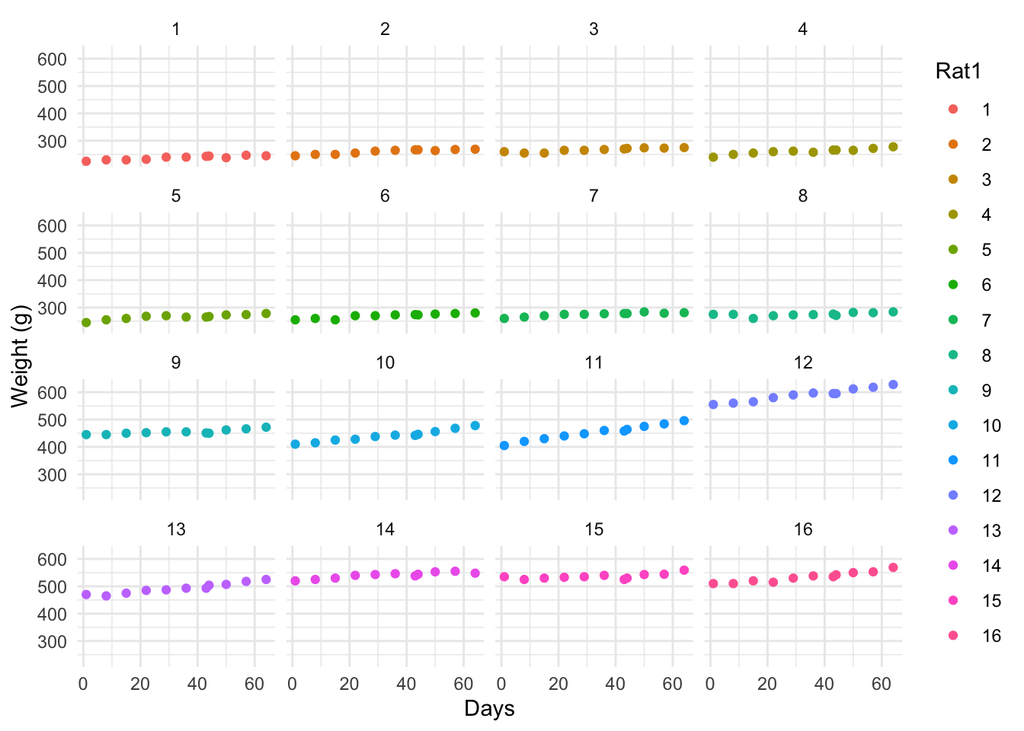

```r
BodyWeight |>
  mutate(Rat1 = factor(as.numeric(Rat))) |>
  ggplot(aes(Time, weight, group = Rat1, color = Rat1)) +
  geom_point() +
  facet_wrap(~Rat1) +
  theme_minimal() +
  labs(x = "Days", y = "Weight (g)")
```

The plot displays the body weights (in grams) of the rats over 64 days at interval of 7 days.

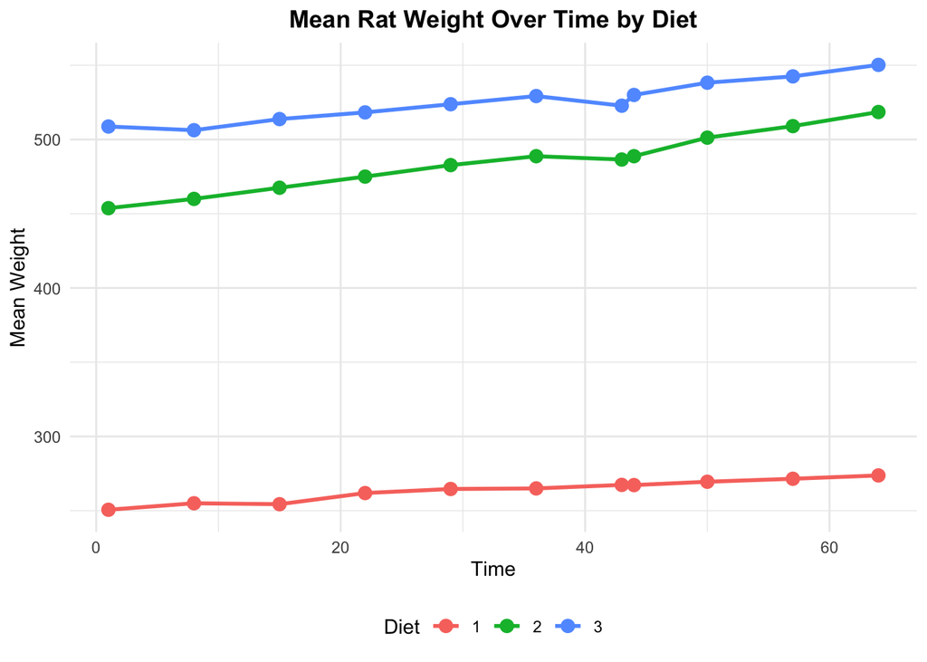

```r
# Calculate mean weights for each Time and Diet combination
mean_weights <- BodyWeight |>
  summarize(mean_weight = mean(weight), .by = c("Time", "Diet"))

mean_weights |> ggplot(aes(x = Time, y = mean_weight, color = Diet, group = Diet)) +
  geom_line(size = 1) +
  geom_point(size = 3) +
  theme_minimal() +
  labs(
    title = "Mean Rat Weight Over Time by Diet",
    x = "Time",
    y = "Mean Weight",
    color = "Diet"
  ) +
  theme(
    legend.position = "bottom",
    plot.title = element_text(hjust = 0.5, face = "bold")
  )
```

The figure showing the mean weight of each type of diet over time displays an increasing trend in the body weight of the rats as the days progress.

# 2 Model Fitting

```r
BodyWeight <- BodyWeight |>
  group_by(Rat) |>
  arrange(weight, .by_group = TRUE) |>
  mutate(initial_weight = first(weight)) |>
  ungroup()
# fit LMM with interaction effect
model1 <- lmer(weight ~ Time * Diet + initial_weight + (1 | Rat), BodyWeight)
summary(model1)
```

```
## Linear mixed model fit by REML. t-tests use Satterthwaite's method [
## lmerModLmerTest]
## Formula: weight ~ Time * Diet + initial_weight + (1 | Rat)
##    Data: BodyWeight
##
## REML criterion at convergence: 1198.1
##
## Scaled residuals:
##     Min      1Q  Median      3Q     Max
## -2.7956 -0.4758 -0.0059  0.4842  3.2162
##
## Random effects:
##  Groups   Name        Variance Std.Dev.
##  Rat      (Intercept) 75.84    8.708
##  Residual             41.02    6.404
## Number of obs: 176, groups:  Rat, 16
##
## Fixed effects:
##                 Estimate Std. Error        df t value Pr(>|t|)
## (Intercept)     13.07809   16.89727  12.11731   0.774    0.454
## Time             0.35964    0.03509 157.00001  10.248  < 2e-16 ***
## Diet2            2.95591   14.90964  12.46144   0.198    0.846
## Diet3            5.08494   18.10691  12.31007   0.281    0.784
## initial_weight   0.96151    0.06673  11.99998  14.408 6.15e-09 ***
## Time:Diet2       0.60584    0.06079 157.00001   9.967  < 2e-16 ***
## Time:Diet3       0.29834    0.06079 157.00001   4.908 2.28e-06 ***
## ---
## Signif. codes:  0 '***' 0.001 '**' 0.01 '*' 0.05 '.' 0.1 ' ' 1
##
## Correlation of Fixed Effects:
##             (Intr) Time   Diet2  Diet3  intl_w Tm:Dt2
## Time        -0.070
## Diet2        0.857  0.079
## Diet3        0.891  0.065  0.913
## initil_wght -0.980  0.000 -0.920 -0.947
## Time:Diet2   0.040 -0.577 -0.137 -0.038  0.000
## Time:Diet3   0.040 -0.577 -0.046 -0.113  0.000  0.333
```

```r
anova(model1)
```

```
## Type III Analysis of Variance Table with Satterthwaite's method
##                 Sum Sq Mean Sq NumDF   DenDF  F value    Pr(>F)
## Time           26193.0 26193.0     1 157.000 638.6116 < 2.2e-16 ***
## Diet               4.1     2.0     2  13.675   0.0497    0.9517
## initial_weight  8514.3  8514.3     1  12.000 207.5865 6.155e-09 ***
## Time:Diet       4190.4  2095.2     2 157.000  51.0833 < 2.2e-16 ***
## ---
## Signif. codes:  0 '***' 0.001 '**' 0.01 '*' 0.05 '.' 0.1 ' ' 1
```

# 3 Model Comparison

```r
# fit LMM with no interaction effect
model2 <- lmer(weight ~ Time + Diet + initial_weight + (1 | Rat), BodyWeight)
```

We will fit a simpler model without the interaction term to see if it could potentially performs as well as `model1`. The simpler model still has `Rat` as a random effect and initial_weight as fixed effect, except `Time` and `Diet` are now the fixed effects.

```r
# compare models
anova(model1, model2)
```

```
## refitting model(s) with ML (instead of REML)
```

```
## Data: BodyWeight
## Models:
## model2: weight ~ Time + Diet + initial_weight + (1 | Rat)
## model1: weight ~ Time * Diet + initial_weight + (1 | Rat)
##        npar    AIC    BIC  logLik deviance  Chisq Df Pr(>Chisq)
## model2    7 1288.7 1310.8 -637.33   1274.7
## model1    9 1212.5 1241.0 -597.23   1194.5 80.196  2  < 2.2e-16 ***
## ---
## Signif. codes:  0 '***' 0.001 '**' 0.01 '*' 0.05 '.' 0.1 ' ' 1
```

# 4 Assumption Checking

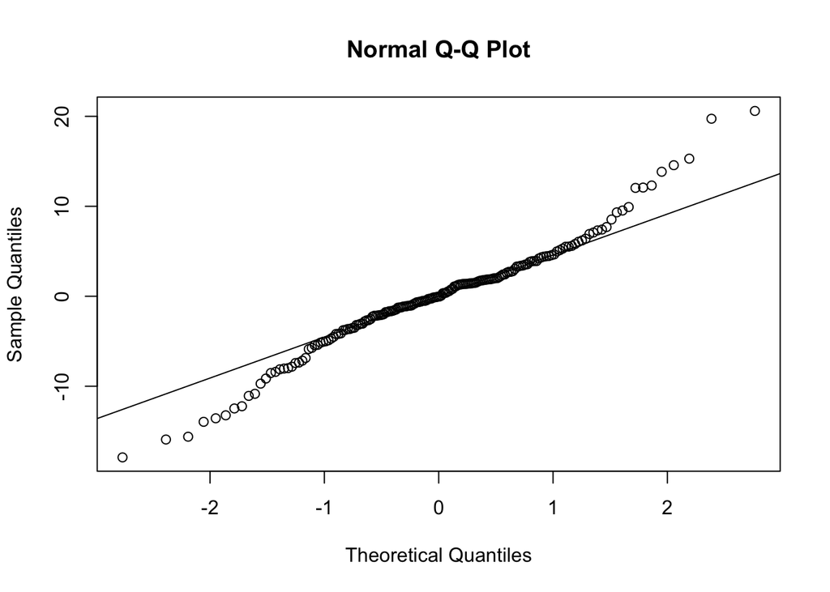

```r
# Normality of residuals
# Extract residuals
residuals <- resid(model1)

# Q-Q plot
qqnorm(residuals)
qqline(residuals)
```

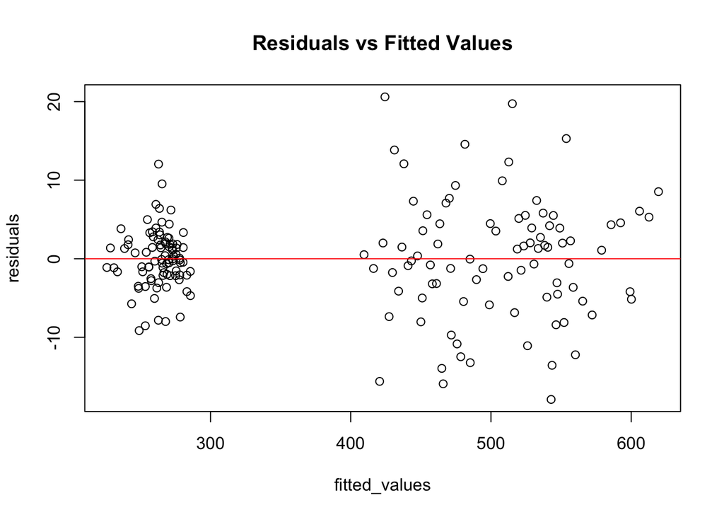

```r
# Homogeneity of Variance
# Fitted values
fitted_values <- fitted(model1)

# Residuals vs Fitted plot
plot(fitted_values, residuals)
abline(h = 0, col = "red")
title("Residuals vs Fitted Values")
```

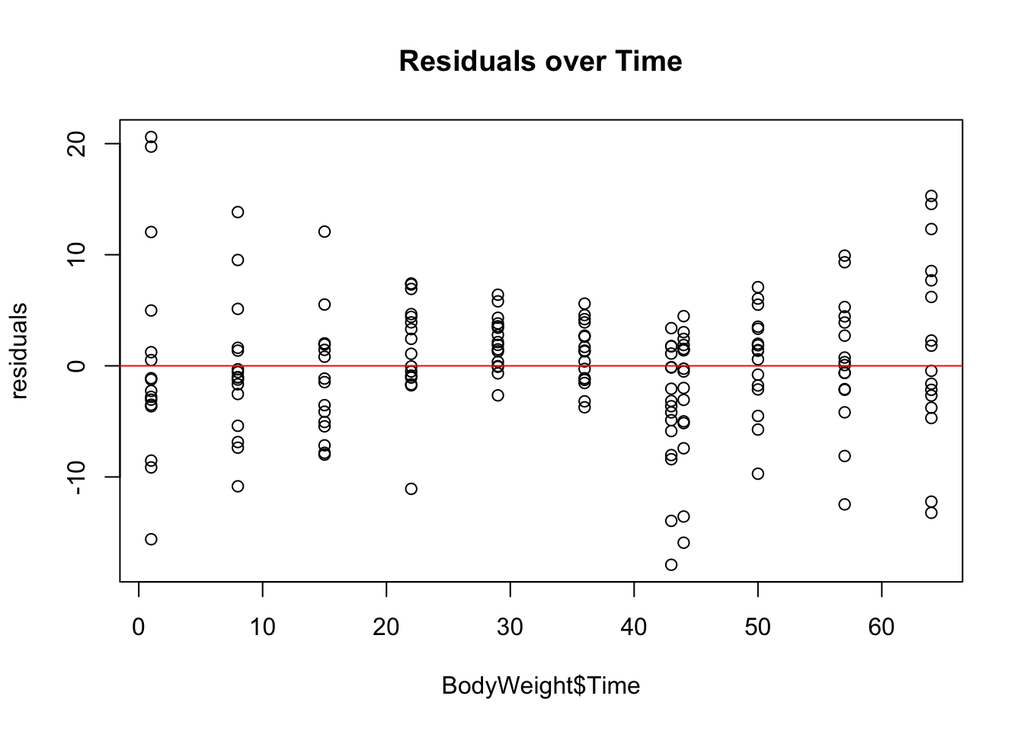

```r
# Residuals over time
plot(BodyWeight$Time, residuals)
abline(h = 0, col = "red")
title("Residuals over Time")
```